# Intro to R - Basics - 2

One should look for what is and not what he thinks should be – Albert Einstein

# Module completion checklist

| Objective | Complete |
| --- | --- |
| Perform basic calculations in R |  |
| Work with variables in R |  |
| Good coding practices for clarity and reproducibility |  |

# RStudio overview

- A default RStudio layout includes 4 panes:
  - **Top left** pane is used as a `Script` pane where you can write and run your code as well as open other R scripts
  - **Bottom left** pane has a `Console`, which shows the output of running R commands
  - **Top right** is a helper pane that shows your `Environment` or `History`
  - **Bottom right** is another helper pane that shows `Files`, static `Plots` and interactive plots through `Viewer`, `Help`, and `Packages`
- As you work in R, you might decide to change the layout by going to **View > Panes > Pane Layout**

# RStudio overview

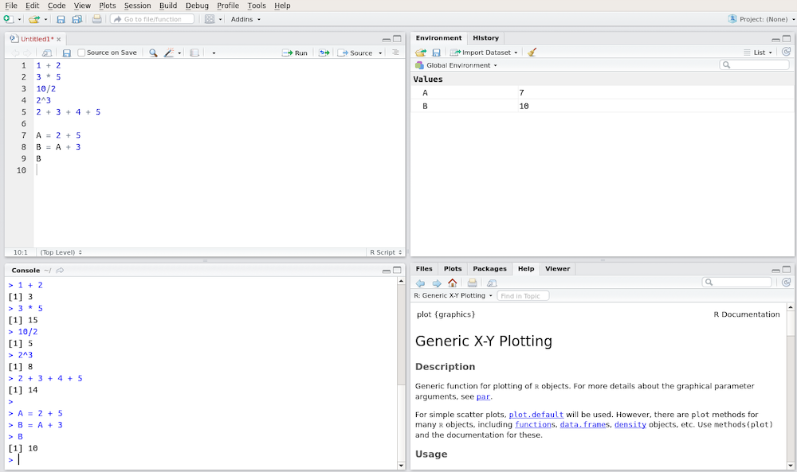

# Executing commands in R

- Code is executed when you press `Run` in the top right corner of the script window
- R runs the line of code where your cursor is located
- You can highlight multiple lines to run at once
- An equivalent command from keyboard to `Run` button is a `Ctrl + Enter` (on PC) or `Command + Enter` (on Mac)

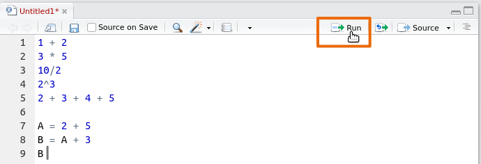

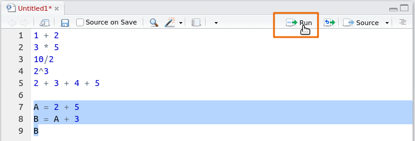

# Basic calculations and operations

- To build some fluency in using R, let’s start with some basic calculations
- **Adding (+)**

```r
# Add whole numbers.
1 + 2
```

```
[1] 3
```

```r
# Add numbers with decimals.
3.23 + 4.65
```

```
[1] 7.88
```

- **Subtracting (-)**

```r
# Subtract whole numbers.
10 - 7
```

```
[1] 3
```

```r
# Subtract numbers with decimals.
3.23 - 4.65
```

```
[1] -1.42
```

# Basic calculations and operations (cont’d)

- **Multiplying (*)**

```r
# Multiply whole numbers.
1 * 2
```

```
[1] 2
```

```r
# Multiply numbers with decimals.
3.23 * 4.65
```

```
[1] 15.0195
```

- **Dividing (/)**

```r
# Divide whole numbers.
9 / 3
```

```
[1] 3
```

```r
# Divide numbers with decimals.
3.23 / 4.65
```

```
[1] 0.6946237
```

# Basic calculations and operations (cont’d)

- **Square roots (sqrt())**

```r
# Take square root of a number with.
sqrt(100)
```

```
[1] 10
```

```r
# Take square root of an expression.
sqrt(7 * 5)
```

```
[1] 5.91608
```

- **Exponents (^ or **)**

```r
# Raise number to a power with `^`.
9 ^ 3
```

```
[1] 729
```

```r
# Raise number to a power with `**`.
9 ** 3
```

```
[1] 729
```

```r
# Raise expression to a power.
(3.23 / 4.65)^2
```

```
[1] 0.482502
```

# Basic calculations and operations (cont’d)

- **Get remainder from division (%%)**

```r
# Get remainder from division.
7 %% 3
```

```
[1] 1
```

```r
# Get remainder from division.
4 %% 2
```

```
[1] 0
```

- **Perform integer division (%/%)**

```r
# Perform integer division.
7 %/% 3
```

```
[1] 2
```

```r
# Perform integer division.
4 %/% 2
```

```
[1] 2
```

# Module completion checklist

| Objective | Complete |
| --- | --- |
| Perform basic calculations in R | **✔** |
| Work with variables in R |  |
| Good coding practices for clarity and reproducibility |  |

# Variables

- In R, a variable is a piece of information to be stored, referenced, and used by a program
- Variables can be assigned any expression, not just numbers
- We can set variables by setting numbers equal to letters or terms using R’s assignment operators, `<-` and `=`

```r
# Define a variable using `<-`
# as an assignment operator.
A <- 3
A
```

```
[1] 3
```

```r
# Define a variable using `=`
# as an assignment operator.
B = 2 + 5
B
```

```
[1] 7
```

# Variables (contd)

- When a variable is named (instantiated), R stores it in its environment
- R uses the values stored within its environment for all calculations within that session
- **Tip:** Check the `Environment` pane for all current objects in your coding session

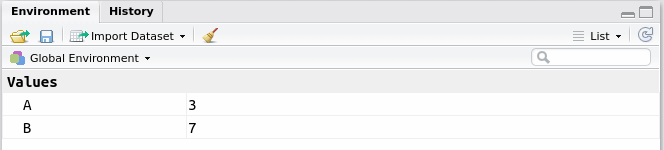

# Operations with variables

**Adding**

- We can add variables

```r
# Add 2 variables.
C = A + B
C
```

```
[1] 10
```

```r
# Add a variable and a number.
D = C + 5
D
```

```
[1] 15
```

**Subtracting**

- We can subtract variables

```r
# Subtract 2 variables from each other.
D - C
```

```
[1] 5
```

```r
# Subtract a variable from number.
33 - D
```

```
[1] 18
```

```r
# Or a number from a variable.
D - 33
```

```
[1] -18
```

- The same stands for **all** other arithmetic operations

# Comparison

- Comparison operators in R are used to compare variables with values or variables to other variables.

```r
# Check variables are equal.
A == B
```

```
[1] FALSE
```

```r
# Check if variables are not equal.
A != B
```

```
[1] TRUE
```

```r
# Check if one is greater than the other.
A > B
```

```
[1] FALSE
```

```r
# Check if one is greater than or equal to 5.
A >= 5
```

```
[1] FALSE
```

```r
# Check if one is less than or equal to 3.
A <= 3
```

```
[1] TRUE
```

```r
# Check if one is smaller than the other.
A < B
```

```
[1] TRUE
```

# Variable value re-assignment

- We can also name variables more descriptively, using strings of text

```r
# 1. Create a variable and assign 67 to it.
this_variable = 67
this_variable
```

```
[1] 67
```

```r
# 2. Create another variable and assign -54.
that_variable = -54
that_variable
```

```
[1] -54
```

```r
# 3. Calculate their sum.
this_variable + that_variable
```

```
[1] 13
```

- We can also re-assign values, variables, and expressions to variables we’ve already used

```r
# 4. Re-assign a value to `this_variable`.
this_variable = 35
this_variable
```

```
[1] 35
```

```r
# 5. Add two variables and store the result
#    in `that_variable`.
that_variable = this_variable + that_variable
that_variable
```

```
[1] -19
```

- Just be sure to keep track and not to overwrite something you didn’t intend to

# Module completion checklist

| Objective | Complete |
| --- | --- |
| Perform basic calculations in R | **✔** |
| Work with variables in R | **✔** |
| Good coding practices for clarity and reproducibility |  |

# Good coding practices: comments

- It’s good practice to leave detailed comments in your code if you intend to collaborate with others
- A **hashmark (#)** is used to add a comment and annotate your code
- Comments can also help with orientation when revisiting previously written code in the future

```r
# This is an example of a comment in R.

A = 2 + 5 #<- you can also add comments at the end of line
B = A + 3
```

# Good coding practices: spacing

- When calling a function or indexing an object, it is a good practice to use a space after each “,” , “<-”, and “=”
- Doing so makes your code more readable, whereas not doing so will make it more cramped and difficult to skim
- Again, both snippets below will run, but one is much easier for human eyes

```r
# This code works but it is difficult to understand
my_object=array(5:20,c(7,8))
my_object<-array(5:20,c(7,8))
my_object[,c(1,2)]


# A clear way to make code readable
my_object = array(5:20, c(7, 8))
my_object <- array(5:20, c(7, 8))
my_object[, c(1, 2)]
```

# Good coding practices: naming conventions

- Function and variable names can use letters, digits, period (`.`) and underscore (`_`)
- They must start with a letter or a period, and if you begin with a period, you cannot follow with a digit
- All the examples below are valid names, but not all are easy to read

```r
# Good
my_variable_name <- -5

# Bad
myvariablename <- -5

# Good
MyFunctionName()
my_function_name()

# Bad
myfunctionname()
```

- Above all else, **be consistent**

# Good coding practices: reserved words

- Reserved words cannot be used as names and can be viewed by running `?reserved` in R

```r
?reserved
```

- You can also access a list of reserved words using the documentation in the `Help` pane

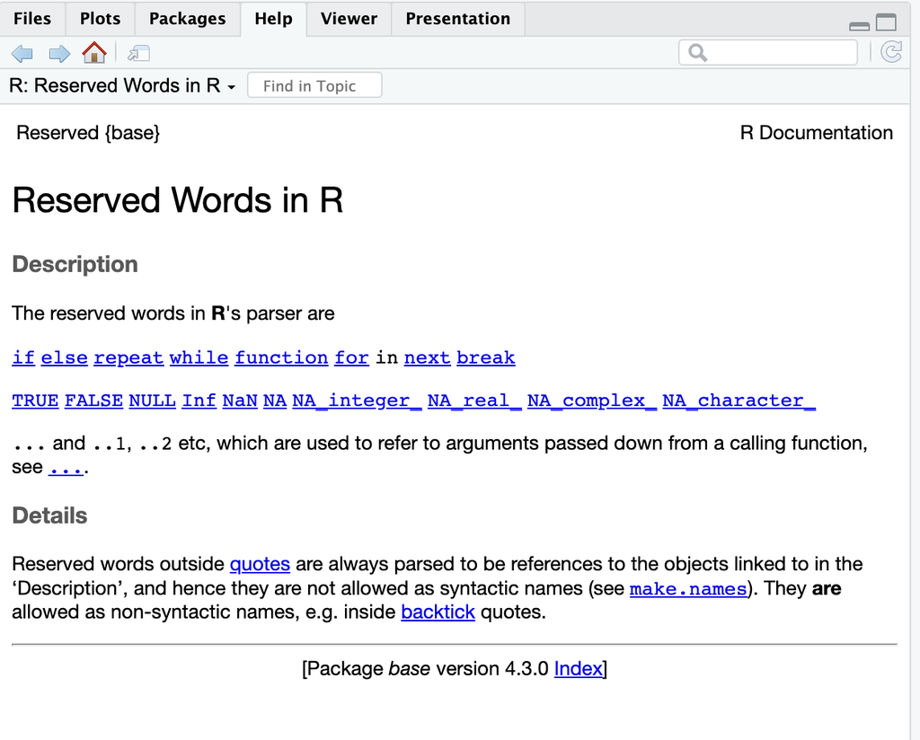

# Good coding practices: libraries first

```r
file_path <- "data.csv"
read.csv(file_path)
library(tidyverse)
```

```bash
Error in file(file, "rt") : cannot open the connection Calls: <Anonymous> ... withVisible( -> eval -> -> read.csv -> read.table -> file
```

# Good coding practices: libraries first (cont’d)

- Your code will often depend on those libraries being in place to run properly
- For this reason, we often call libraries dependencies, which should be accounted for in code before any tasks are performed
- The code below begins by importing the library, then specifying variables, and finally performing a certain operation

```r
library(readr)

my_list <- list(2,4,8)
file_path <- "data.csv"

read.csv(file_path)
```

# Knowledge check

# Exercise

You are now ready to try Tasks 1-12 in the Exercise for this topic

# Module completion checklist

| Objective | Complete |
| --- | --- |
| Use RStudio to write and execute R code |  |
| Perform basic calculations in R | **✔** |
| Work with variables in R | **✔** |
| Good coding practices for clarity and reproducibility | **✔** |

# Basics: Topic summary

In this part of the course, we have covered:

- Overview of Data Science and its tools
- R and RStudio as tools in data analysis and their features
- Basic calculations in R

# Congratulations on completing this module!